# 2025.08.18 Muon technical challenge

**Instructions:**

> We instrumented our reaction wheel in the lab. Over time, we recorded the current that we commanded and the unit’s reported wheel speed. We want to make a model of this for two reasons:
> - We want to use the model in our simulation so that we have realistic wheel responses.
> - We may use the same mathematical model in our flight software as a feed-forward on reaction wheel commands. (If there's *this* much friction, then you need to actually push *this* hard to get the resulting acceleration that you want.)

> A CSV of the experiment is attached. The goal of the exercise is to create a model that fits this data, describe the model, and show how well it fits. Here are a few notes (not strictly necessary for solving the problem): The rotor inertia is 0.001 kg m^2.The unit does not have a closed loop on commanded current. The power bus voltage was held steady at 26V throughout. We ask folks to limit the time they spend on this to 3 hours, and to return it to us within a few days of us sending it over. The point is to show a good approach, not to model every last nuance.

## 0.0 import data

```python
import csv
import numpy as np

times = []
I_meas = []
omega_meas = []

with open('data/reaction-wheel-test-results.csv', 'r', newline='') as csvfile:
    # Create a CSV reader object
    csv_reader = csv.reader(csvfile)

    # Skip the header row if present
    header = next(csv_reader)
    print(f"Header: {header}")

    # Iterate over each row in the CSV file
    for row in csv_reader:
        times.append(float(row[0]))
        I_meas.append(float(row[1]))
        omega_meas.append(int(row[2]))


times = np.array(times)
I_meas = np.array(I_meas)
omega_meas = np.array(omega_meas)

print(f"Time shape: {times.shape}")
print(f"I shape: {I_meas.shape}")
print(f"Omega shape {omega_meas.shape}")
```

```
Header: ['Time (s)', ' Commanded Current (A)', ' Wheel Speed (RPM)']
Time shape: (6001,)
I shape: (6001,)
Omega shape (6001,)
```

## 1.0 plot data

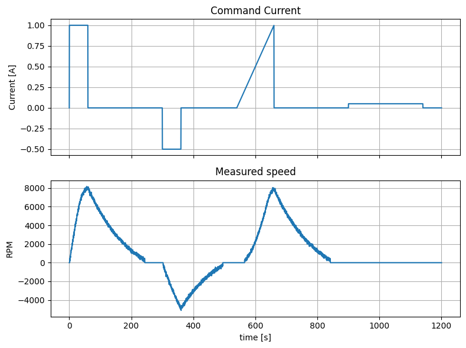

```python
import matplotlib.pyplot as plt

# Create figure and subplots
fig, (ax1, ax2) = plt.subplots(2, 1, figsize=(8, 6), sharex=True)

# First plot (top)
ax1.plot(times, I_meas)
ax1.set_title('Command Current')
ax1.set_ylabel('Current [A]')
ax1.grid(True)

# Second plot (bottom)
ax2.plot(times, omega_meas)
ax2.set_title('Measured speed')
ax2.set_xlabel('time [s]')
ax2.set_ylabel('RPM')
ax2.grid(True)

# Adjust layout to prevent overlap
plt.tight_layout()
# Display the plot
plt.show()
```

## 2.0 analytical model

A simple analytical model for this reaction wheel takes into account four terms:

1. Inertia.
2. Torque due to the motor.
3. Viscous friction/drag proportional to velocity.
4. Coulomb friction term, significant at low velocity. Enables a stick/slip behavior.

$$ \begin{align} J \dot{\omega} &= \tau_{motor} - \tau_{drag} - \tau_{coulomb friction}\\ J \dot {\omega} &= k I - b \omega - c * \tanh{\omega} \end{align} $$

where

- $I $ is the current [$A$]
- $k$ is the motor torque constant [$\frac{N m}{A}$]
- $b$ is the drag coefficient [$\frac{N m s}{rad}$]
- $\omega$ is angular velocity [$\frac{rad}{s}$]
- $J$ rotational inertia of reaction wheel [$kg m^2$]

This is a reasonably rough model. Based on some of the [literature](https://www.researchgate.net/publication/258391329_Estimating_Friction_Parameters_in_Reaction_Wheels_for_Attitude_Control) there are ways I could make this model higher fidelity. But given the scope of this challenge, I am going to call this sufficient.

Before we start fitting the model, we need to clean up our data.

## 3.0 clean up angular velocity data

As a first step, let's apply some sort of low pass filter to remove the higher frequency noise that is visable in the above plot. There are many different types of low pass filters. Three possible ones I could apply are:

1. Moving average filter - this filter just assigns each point the average of the value of the points around it in some window.
2. Gaussian filter - Similar to moving average, but uses a gaussian kernel to apply more weight to central points in the window.
3. Butterworth filter - Converts data to frequency domain and attenuates frequencies above a certain threshold.

Given that this is a nominally three hour challenge, I am just going to implement the moving average filter and inspect the result.

The result below looks decent. I am going to proceed and come back to this step later if need be.

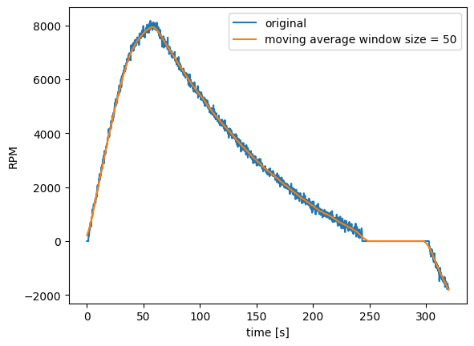

```python
import numpy as np
from scipy.signal import butter, filtfilt

def box_filter(data, window_size):

    # "same" enforces filtered data to be the same size as input data by padding the array with zeros.
    filtered = np.convolve(data, np.ones(window_size)/window_size, mode='same')

    return filtered

omega_meas_filtered = box_filter(omega_meas, 50)

plt.plot(times[:1600], omega_meas[:1600], label="original")
plt.plot(times[:1600], omega_meas_filtered[:1600], label="moving average window size = 50")
plt.legend()
plt.xlabel("time [s]")
plt.ylabel("RPM")
```

## 4.0 Fit model

First, let's write out our kinematics equation from above, and play around with different values to gather an initial guess for the three unknown constants $k$ (motor torque constant) and $b$ (drag coefficient) and $c$ (coulumb friction coefficient).

### 4.1 Preliminary fit by guessing at parameters

```
LS error cost is 4.437435e+08
```

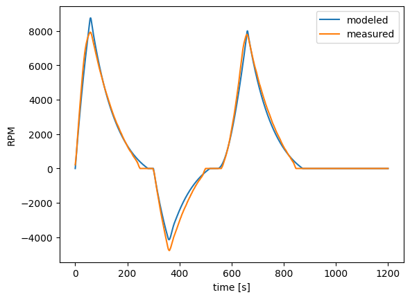

```python
from scipy.integrate import solve_ivp

def omega_dot(t, omega, I_meas, t_meas, k_norm, b_norm, c_norm, divisors, J=0.001):

    k_div, b_div, c_div = divisors
    k, b, c = k_norm/k_div, b_norm/b_div, c_norm/c_div

    # interpolate current from time series measurements
    I = np.interp(t, t_meas, I_meas)

    # This '5' is picked somewhat arbitartily and dictates how steep the smoothed step function is.
    omega_tanh = np.tanh(5*omega)

    return (k * I - b * omega - c * omega_tanh) / J


t_span = (times[0], times[-1])
y0 = np.array([0])


# initial estimate for normalized parameters based on grid search.
k0, b0, c0 = 2.1, 1.0, 1.1

# The above parameters are normalized. To get back to the actual value, divide by these divisors. Order [k, b, c]
parameter_divisors = [1e1, 1e5, 1e2]

ret = solve_ivp(omega_dot, y0=y0, t_span=t_span, t_eval=times, args=(I_meas, times, k0, b0, c0, parameter_divisors))

plt.plot(ret.t, ret.y[0], label="modeled")
plt.plot(times, omega_meas_filtered, label="measured")
plt.xlabel("time [s]")
plt.ylabel("RPM")
plt.legend()

print(f"LS error cost is {np.linalg.norm(omega_meas_filtered - ret.y[0])**2:e}")
```

### 4.3 Least squares estimation of drag coefficients

To estimate the two drag coefficients, let's simplify the system by *only* considering the data where there is *no* current and therfore only the drag forces are relevant.

Let's consider the domain:

- (300, 1500)

In that domain, the equations can be simplified to be:

$$ \begin{align} J \dot{\omega} &= - \tau_{drag} - \tau_{coulomb friction}\\ J \dot {\omega} &= - b \omega - c * \tanh{\omega} \end{align} $$

```python
from scipy.optimize import least_squares

def omega_dot_drag(t, omega, b_norm, c_norm, divisors, J=0.001):
    b_div, c_div = divisors[0], divisors[1]
    b, c = b_norm/b_div, c_norm/c_div

    omega_tanh = np.tanh(5*omega)

    return (- b * omega - c * omega_tanh) / J

def residuals_drag(params, times, omega_meas, param_divisors):
    b_norm, c_norm = params

    t_span=(times[0], times[-1])

    sol = solve_ivp(omega_dot_drag, y0=np.array([omega_meas[0]]), t_eval=times, t_span=t_span, args=(b_norm, c_norm, param_divisors))

    #print(f"Cost {0.5 * np.linalg.norm(sol.y[0] - omega_meas)**2:e}")
    return sol.y[0] - omega_meas


drag_idx_1, drag_idx_2 = 300, 1500
drag_times = times[drag_idx_1:drag_idx_2]
omega_meas_filtered_drag = omega_meas_filtered[drag_idx_1:drag_idx_2]

initial_params = np.array([1.0, 1.1])
param_divisors_drag = [1e5, 1e2]


# Run nonlinear least squares
result = least_squares(residuals_drag, initial_params, args=(drag_times, omega_meas_filtered_drag, param_divisors_drag), verbose=2)
```

```
   Iteration     Total nfev        Cost      Cost reduction    Step norm     Optimality
       0              1         5.7946e+07                                    5.85e+08
       1              2         5.8788e+06      5.21e+07       8.92e-01       2.82e+08
       2              3         7.7215e+05      5.11e+06       1.32e-01       7.03e+06
       3              4         7.4543e+05      2.67e+04       3.53e-02       1.43e+05
       4              5         7.4543e+05      2.61e+00       2.68e-04       1.81e+02
       5              6         7.4543e+05      4.68e-06       3.81e-07       2.94e+00
`ftol` termination condition is satisfied.
Function evaluations 6, initial cost 5.7946e+07, final cost 7.4543e+05, first-order optimality 2.94e+00.
```

```
Least squares error: 7.454266e+05
b = 0.6381623029154728 and c = 2.0848139139482
```

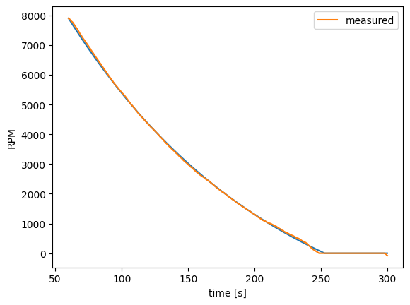

```python
b, c = result.x
t_span = (drag_times[0], drag_times[-1])
ret = solve_ivp(omega_dot_drag, y0=np.array([omega_meas_filtered_drag[0]]), t_span=t_span, t_eval=drag_times, args=(b, c, param_divisors_drag))

t_ls, omega_simulated_ls = ret.t, ret.y[0]

print(f"Least squares error: {0.5* np.linalg.norm(omega_simulated_ls - omega_meas_filtered_drag)**2:e}")
print(f"b = {b} and c = {c}")

plt.plot(ret.t, omega_simulated_ls)
plt.plot(drag_times, omega_meas_filtered_drag, label="measured")
plt.xlabel("time [s]")
plt.ylabel("RPM")
plt.legend()
```

That looks pretty good! The values we calculated where $b=0.638$ and $c=2.0848$. Now let's try to solve for the motor constant!

```python
B_FINAL = b
C_FINAL = c
```

### 4.4 Least squares to solve for $k$

I again run the least squared optmizer on a subset of the data because I was running into challenges when running the optimizer on the whole range. Specifically, the cost space appeared to be flat or noisy enough that the optimizer was returning the input as the output.

To estimate $k$, I focus on the data in the initial reaction wheel ramp up period.

```python
from scipy.optimize import least_squares

times_first_pulse = times[0:300]
I_first_pulse = I_meas[0:300]
omega_first_pulse = omega_meas_filtered[0:300]

def residuals(params, b, c, times, I_meas, omega_meas, param_divisors):
    k_norm = params[0]

    t_span=(times[0], times[-1])

    sol = solve_ivp(omega_dot, y0=np.array([omega_meas[0]]), t_eval=times, t_span=t_span, args=(I_meas, times, k_norm, b, c, param_divisors))

    print(f"Cost {0.5 * np.linalg.norm(sol.y[0] - omega_meas)**2:e}")
    return sol.y[0] - omega_meas

initial_params = np.array([k0])

# Run nonlinear least squares
result = least_squares(residuals, initial_params, args=(B_FINAL, C_FINAL, times_first_pulse, I_first_pulse, omega_first_pulse, parameter_divisors), verbose=2)

K_FINAL = result.x[0]
```

```
Cost 4.136058e+07
Cost 4.136058e+07
   Iteration     Total nfev        Cost      Cost reduction    Step norm     Optimality
       0              1         4.1361e+07                                    1.37e+08
Cost 3.786886e+07
Cost 3.786886e+07
       1              2         3.7869e+07      3.49e+06       5.08e-02       1.54e+03
Cost 3.786886e+07
Cost 3.786886e+07
       2              3         3.7869e+07      4.36e-04       5.70e-07       3.89e-01
`ftol` termination condition is satisfied.
Function evaluations 3, initial cost 4.1361e+07, final cost 3.7869e+07, first-order optimality 3.89e-01.
```

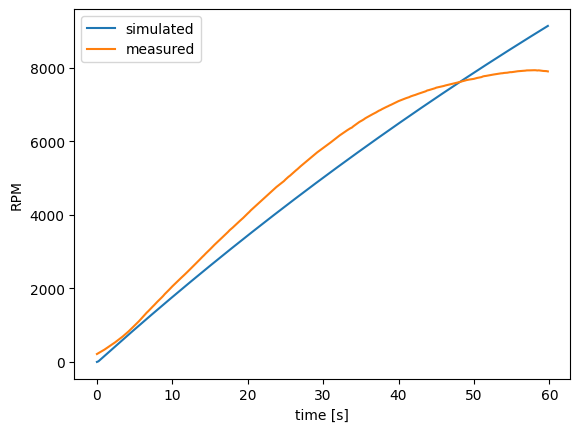

```python
t_span = (times_first_pulse[0], times_first_pulse[-1])

ret = solve_ivp(omega_dot, y0=np.array([0]), t_span=t_span, t_eval=times_first_pulse, args=(I_first_pulse, times_first_pulse, K_FINAL, B_FINAL, C_FINAL, parameter_divisors))

t, omega = ret.t, ret.y[0]

plt.plot(ret.t, ret.y[0], label="simulated")
plt.plot(times_first_pulse, omega_first_pulse, label="measured")
plt.xlabel("time [s]")
plt.ylabel("RPM")
plt.legend()
```

The results are not as good as they were for the drag coefficients!

**I think that modeling torque as a linear function of current independent of angular velocity is insufficient.** It appears that the torque falls off at larger angular velocities.

### 4.5 Propagating the full solution based on the values for $k$, $b$, and $c$.

Regardless, for the sake of this exercise we are going to continue with the values we calculated. $$ k = 2.049188 \times 10^{-1} \\ b = 6.381623 \times 10^{-6} \\ c = 2.084814 \times 10^{-2} $$

The final kinematic equation becomes

$$ \begin{align} \dot {\omega} &= (2.049188 \times 10^2) I - (6.381623 \times 10^{-3}) \omega - (2.084814 \times 10^1) * \tanh{\omega} \end{align} $$

```
k = 2.049188e-01 , b = 6.381623e-06, c = 2.084814e-02
Least squares error: 5.599089e+08
```

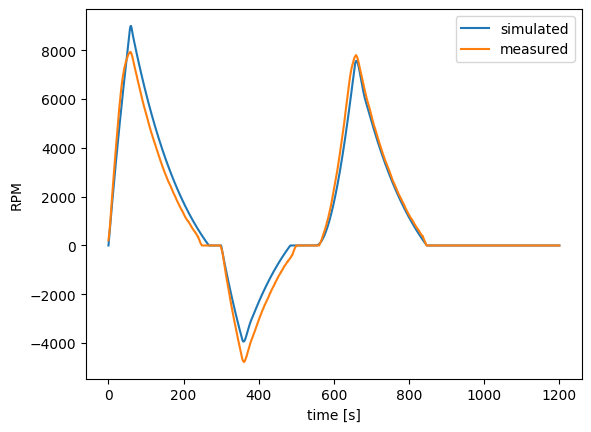

```python
t_span=(times[0], times[-1])
ret = solve_ivp(omega_dot, y0=y0, t_span=t_span, t_eval=times, args=(I_meas, times, K_FINAL, B_FINAL, C_FINAL, parameter_divisors))

t_ls, omega_simulated_ls = ret.t, ret.y[0]


print(f"k = {K_FINAL/parameter_divisors[0]:5e} , b = {B_FINAL/parameter_divisors[1]:5e}, c = {C_FINAL/parameter_divisors[2]:5e}")

print(f"Least squares error: {0.5* np.linalg.norm(omega_simulated_ls - omega_meas_filtered)**2:e}")

plt.plot(ret.t, omega_simulated_ls, label="simulated")
plt.plot(times, omega_meas_filtered, label="measured")
plt.xlabel("time [s]")
plt.ylabel("RPM")
plt.legend()
```

### 4.6 Solving least squares problem for all three variables for all time steps at once.

It is attractive to solve the the least squared problem for all three parameters and all time steps simultaneously. However, in practice I have found that the cost function space is sufficiently noisy or flat, that the output of such an optimization is identical to the input.

## 5.0 Review of uncertainty/error

Let's consider a couple metrics against the orginal unfiltered angular velocity data.

```
Least squares error: 5.599089e+08
```

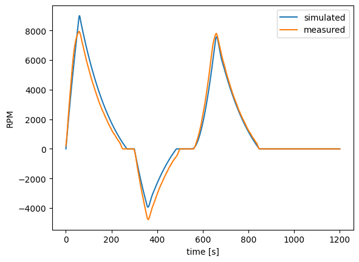

```python
t_span=(times[0], times[-1])
ret = solve_ivp(omega_dot, y0=y0, t_span=t_span, t_eval=times, args=(I_meas, times, K_FINAL, B_FINAL, C_FINAL, parameter_divisors))

t_ls, omega_simulated_ls = ret.t, ret.y[0]

print(f"Least squares error: {0.5* np.linalg.norm(omega_simulated_ls - omega_meas_filtered)**2:e}")

plt.plot(ret.t, omega_simulated_ls, label="simulated")
plt.plot(times, omega_meas_filtered, label="measured")
plt.xlabel("time [s]")
plt.ylabel("RPM")
plt.legend()
```

```python
print(f"Mean squared error: {0.5* np.sum((omega_simulated_ls - omega_meas)**2):e}")
print(f"Max absolute error {np.max(np.abs(omega_simulated_ls - omega_meas))}")
print(f"Root mean squared error: {np.mean(omega_simulated_ls - omega_meas)}")
```

[output not shown]

## 6.0 Future points for improvement

1. I think my drag model is reasonably good. I think more of the errors are coming from the current -> torque model. At the moment I assume a linear relation between current and torque _independent_of angular velocity. In reality, I bet torque falls off at higher angular velocities.
2. I did not read too closely, but it looks like there are some clever ways to model the low-velocity columbic drag that might be more accurate than my smoothed out step function model.